# Inspect DDI variables over time - Defunciones No Fetales

```r
ddi_defun_nofetal_vars <- tar_read(ddi_defun_nofetal_vars)
```

While `inspect_vars_info_defun_nofetal.Rmd` looks at the data *as ingested* from the .sav files (`defun_nofetal_raw`), this notebook looks at the *documented* metadata, i.e. the DDI codebooks (`ddi_defun_nofetal_vars`), for Defunciones No Fetales (non-fetal/general deaths). The DDI is what tells us how a variable is supposed to be encoded (its measurement type, its label, and the value/label pairs for its categories), independently of whatever ended up in the actual data file for a given year. Here we want to answer:

- which variables does DANE actually document, and in which years
- does a variable’s measurement type (`intrvl`) or label text stay stable over time
- how many categories does each variable have per year, and does the DDI actually include a label for each of them (some years/variables only document the codes, not the labels – this is what broke DDI ingestion for 2023/2024, see `ingest_eevv_ddi.R`)
- for variables with a manageable number of categories, which codes are added/dropped over time, and does the label text for the same code drift (spelling, accents, rewording) across years

```r
ddi_summary <- ddi_defun_nofetal_vars |>
  mutate(
    n_categories = purrr::map_int(catgry, nrow),
    n_missing_label = purrr::map_int(catgry, \(x) sum(is.na(x$labl))),
    pct_missing_label = dplyr::if_else(
      n_categories > 0, n_missing_label / n_categories, NA_real_
    )
  )
```

# Coverage: variables documented per year

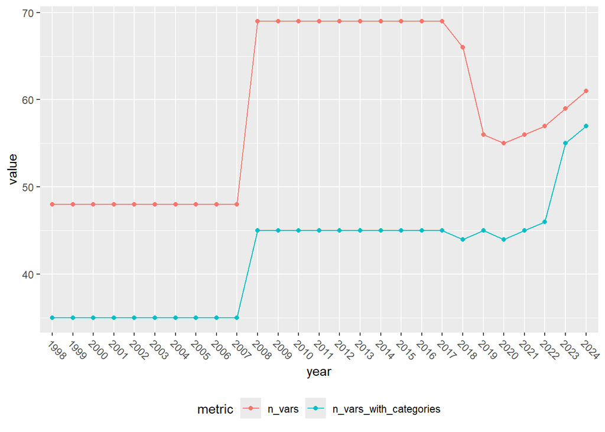

```r
ddi_summary |>
  group_by(year) |>
  summarize(
    n_vars = n(),
    n_vars_with_categories = sum(n_categories > 0),
    .groups = "drop"
  ) |>
  tidyr::pivot_longer(starts_with("n_vars"), names_to = "metric") |>
  ggplot(aes(x = year, y = value, color = metric, group = metric)) +
  geom_line() +
  geom_point() +
  theme(axis.text.x = element_text(angle = -45, hjust = 0), legend.position = "bottom")
```

```r
plotly::ggplotly(
  ddi_summary |>
    ggplot(aes(
      x = year, y = name, fill = n_categories,
      text = glue::glue(
        "\n",
        "intrvl: {intrvl}",
        "label: {labl}",
        "n_categories: {n_categories}",
        "n_missing_label: {n_missing_label}",
        .sep = "\n"
      )
    )) +
    geom_tile() +
    scale_fill_viridis_c(trans = "log1p", na.value = "grey90")
) |>
  plotly::layout(
    legend = list(orientation = "h"), xaxis = list(title = NA, tickangle = -45)
  )
```

[interactive chart not shown]

# Measurement type (`intrvl`) over time

```r
plotly::ggplotly(
  ddi_summary |>
    ggplot(aes(
      x = year, y = name, fill = intrvl,
      text = glue::glue(
        "\n",
        "intrvl: {intrvl}",
        "label: {labl}",
        .sep = "\n"
      )
    )) +
    geom_tile()
) |>
  plotly::layout(
    legend = list(orientation = "h"), xaxis = list(title = NA, tickangle = -45)
  )
```

[interactive chart not shown]

Variables whose `intrvl` is not the same across every year they appear in (worth a manual look, a future `homologate_vars_defun_nofetal()` may need to cast them explicitly):

```r
ddi_summary |>
  group_by(name) |>
  summarize(
    n_types = n_distinct(intrvl, na.rm = TRUE),
    types = paste(sort(unique(intrvl)), collapse = ", "),
    years = paste(sort(unique(year)), collapse = ", "),
    .groups = "drop"
  ) |>
  filter(n_types > 1) |>
  DT::datatable()
```

|  | name | n_types | types | years |
| --- | --- | --- | --- | --- |
| 1 | causa_666 | 2 | contin, discrete | 1998, 1999, 2000, 2001, 2002, 2003, 2004, 2005, 2006, 2007, 2008, 2009, 2010, 2011, 2012, 2013, 2014, 2015, 2016, 2017 |
| 2 | causa_667 | 2 | contin, discrete | 2018, 2019, 2020, 2021, 2022, 2023, 2024 |
| 3 | edad_madre | 2 | contin, discrete | 1998, 1999, 2000, 2001, 2002, 2003, 2004, 2005, 2006, 2007, 2008, 2009, 2010, 2011, 2012, 2013, 2014, 2015, 2016, 2017, 2018, 2019, 2020, 2021, 2022, 2023, 2024 |
| 4 | ultcurfal | 2 | contin, discrete | 2008, 2009, 2010, 2011, 2012, 2013, 2014, 2015, 2016, 2017, 2018, 2019, 2020, 2021, 2022, 2023, 2024 |

# Variable label (`labl`) consistency over time

The variable label is free text, so it is expected to drift a bit (accents, capitalization). Still, worth a look to catch actual renames (a variable being repurposed) as opposed to just cosmetic differences. This is the same kind of check `get_var_labels_only()` already does to pick one label per variable; here we show the years in which each wording was used.

```r
label_changes <- ddi_summary |>
  group_by(name) |>
  summarize(n_labels = n_distinct(labl), .groups = "drop") |>
  filter(n_labels > 1)

ddi_summary |>
  semi_join(label_changes, by = "name") |>
  group_by(name, labl) |>
  summarize(years = paste(sort(unique(year)), collapse = ", "), .groups = "drop") |>
  arrange(name) |>
  DT::datatable()
```

|  | name | labl | years |
| --- | --- | --- | --- |
| 1 | a_defun | Área de la defunción | 1998, 1999, 2000, 2001, 2002, 2003, 2004, 2005, 2006, 2007 |
| 2 | a_defun | Área donde ocurrió la defunción | 2008, 2009, 2010, 2011, 2012, 2013, 2015, 2016, 2017, 2018, 2019, 2020, 2021, 2022, 2023, 2024 |
| 3 | a_defun | área donde ocurrió la defunción | 2014 |
| 4 | ano | Año en que ocurrió la defunción | 1998, 1999, 2000, 2001, 2002, 2003, 2004, 2005, 2006, 2007, 2008, 2009, 2010, 2011, 2012, 2013, 2015, 2016, 2017, 2018, 2019, 2020, 2021, 2022, 2023, 2024 |
| 5 | ano | año en que ocurrió la defunción | 2014 |
| 6 | area_res | Área de residencia habitual del fallecido | 1998, 1999, 2000, 2001, 2002, 2003, 2004, 2005, 2006, 2007 |
| 7 | area_res | Área de residencia habitual del fallecido (para muerte fetal o de menor de un año la de la madre) | 2020 |
| 8 | area_res | Área de residencia habitual del fallecido (para muerte fetal o de menor de un año la el de la madre) | 2008, 2009, 2010, 2011, 2012, 2013, 2015, 2016, 2017, 2018, 2019, 2021, 2022, 2023, 2024 |
| 9 | area_res | área de residencia habitual del fallecido (para muerte fetal o de menor de un año la el de la madre) | 2014 |
| 10 | asis_med | Recibió asistencia médica durante el proceso que lo llevo a la muerte? | 1998, 1999, 2000, 2001, 2002, 2003, 2004, 2005, 2006, 2007, 2008, 2009, 2010, 2011, 2012, 2013, 2015, 2016, 2017, 2018, 2019, 2020, 2021, 2022, 2023, 2024 |

[output cut: 160 more lines]

# Missing category labels

Some years document the category *codes* for a variable but not their *labels* (`catValu` without a `labl`) – this is what made DDI ingestion of 2023/2024 fail in the first place (see `ingest_eevv_ddi.R` / `daner::get_var_categories()`), and it is worth monitoring going forward, since it silently limits what `encode_ddi_factor()` can do with that year/variable. The heatmap below shows the share of categories missing a label (0% = fully labeled, white = no categories documented at all).

```r
plotly::ggplotly(
  ddi_summary |>
    filter(n_categories > 0) |>
    ggplot(aes(
      x = year, y = name, fill = pct_missing_label,
      text = glue::glue(
        "\n",
        "n_categories: {n_categories}",
        "n_missing_label: {n_missing_label}",
        .sep = "\n"
      )
    )) +
    geom_tile() +
    scale_fill_viridis_c(limits = c(0, 1), labels = scales::percent)
) |>
  plotly::layout(
    legend = list(orientation = "h"), xaxis = list(title = NA, tickangle = -45)
  )
```

[interactive chart not shown]

# Category codes over time (small code lists)

```r
small_vars <- ddi_summary |>
  group_by(name) |>
  summarize(max_n = max(n_categories), .groups = "drop") |>
  filter(max_n > 0, max_n <= 15) |>
  arrange(name) |>
  pull(name)

catgry_small <- ddi_defun_nofetal_vars |>
  filter(name %in% small_vars) |>
  select(name, year, catgry) |>
  tidyr::unnest(catgry)

purrr::walk(small_vars, function(v) {
  cat("## ", v, "\n\n")

  p <- catgry_small |>
    filter(name == v) |>
    ggplot(aes(
      x = year, y = catValu, fill = catValu,
      text = glue::glue("labl: {labl}")
    )) +
    geom_tile() +
    theme(legend.position = "none")

  print(htmltools::tagList(
    plotly::ggplotly(p) |>
      plotly::layout(xaxis = list(title = NA, tickangle = -45))
  ))

  cat("\n\n")
})
```

## a_defun

[interactive chart not shown]

## ano

[interactive chart not shown]

## area_res

[interactive chart not shown]

## asis_med

[interactive chart not shown]

## c_muerte

[interactive chart not shown]

## c_muerteb

[interactive chart not shown]

## c_muertec

[interactive chart not shown]

## c_muerted

[interactive chart not shown]

## c_muertee

[interactive chart not shown]

## c_muertef

[interactive chart not shown]

## c_muerteg

[interactive chart not shown]

## codpaisnacmad

[interactive chart not shown]

## cons_exp

[interactive chart not shown]

## edad_madre

[interactive chart not shown]

## emb_fal

[interactive chart not shown]

## emb_mes

[interactive chart not shown]

## emb_sem

[interactive chart not shown]

## est_civil

[interactive chart not shown]

## est_civm

[interactive chart not shown]

## gru_ed2

[interactive chart not shown]

## idadmisalu

[interactive chart not shown]

## idadmisalud

[interactive chart not shown]

## idpertet

[interactive chart not shown]

## idprofcer

[interactive chart not shown]

## man_muer

[interactive chart not shown]

## mes

[interactive chart not shown]

## mu_parto

[interactive chart not shown]

## muerteporo

[interactive chart not shown]

## n_hijosm

[interactive chart not shown]

## niv_edum

[interactive chart not shown]

## nivel_edu

[interactive chart not shown]

## p_pman_iris

[interactive chart not shown]

## peso_nac

[interactive chart not shown]

## pman_muer

[interactive chart not shown]

## regsocialmadre

[interactive chart not shown]

## seg_social

[interactive chart not shown]

## sexo

[interactive chart not shown]

## simuertepo

[interactive chart not shown]

## sit_defun

[interactive chart not shown]

## t_ges

[interactive chart not shown]

## t_ges_agru_cie

[interactive chart not shown]

## t_parto

[interactive chart not shown]

## tipo_defun

[interactive chart not shown]

## tipo_emb

[interactive chart not shown]

## tipoformulario

[interactive chart not shown]

## ultcurmad

[interactive chart not shown]

# Category label drift for persisting codes

For a code (`catValu`) that shows up in more than one year for the same variable, does its label text actually stay the same? Small wording/accent differences are expected and harmless; a code being re-labelled to mean something substantively different is the thing worth catching here.

```r
ddi_defun_nofetal_vars |>
  select(name, year, catgry) |>
  tidyr::unnest(catgry) |>
  filter(!is.na(labl)) |>
  group_by(name, catValu) |>
  summarize(
    n_distinct_labl = n_distinct(labl),
    labels = paste(unique(labl), collapse = " | "),
    years = paste(sort(unique(year)), collapse = ", "),
    .groups = "drop"
  ) |>
  filter(n_distinct_labl > 1) |>
  arrange(name, catValu) |>
  DT::datatable()
```

|  | name | catValu | n_distinct_labl | labels | years |
| --- | --- | --- | --- | --- | --- |
| 1 | c_muerte | 1 | 2 | Necropsia \| Necropsia médicolegal | 1998, 1999, 2000, 2001, 2002, 2003, 2004, 2005, 2006, 2007, 2008, 2009, 2010, 2011, 2012, 2013, 2014, 2015, 2016, 2017, 2018, 2019, 2020, 2021, 2022, 2023, 2024 |
| 2 | c_muerte | 9 | 2 | sin información \| Sin información | 1998, 1999, 2000, 2001, 2002, 2003, 2004, 2005, 2006, 2007 |
| 3 | c_muertec | 1 | 2 | Pruebas de laboratorio \| Pruebas diagnosticas | 2008, 2009, 2010, 2011, 2012, 2013, 2014, 2015, 2016, 2017, 2018, 2019, 2020, 2021, 2022, 2023, 2024 |
| 4 | c_muerted | 1 | 2 | Interrogatorio a familiares o testigos \| Interrogatorio a familiares | 2008, 2009, 2010, 2011, 2012, 2013, 2014, 2015, 2016, 2017, 2018, 2019, 2020, 2021, 2022, 2023, 2024 |
| 5 | c_muertee | 1 | 2 | Sin información \| Necropsia clinica | 2008, 2009, 2010, 2011, 2012, 2013, 2014, 2015, 2016, 2017, 2018, 2019, 2020, 2021, 2022, 2023, 2024 |
| 6 | codocur | 01 | 2 | Sin información de departamento, \| Sin información de departamento | 1998, 1999, 2000, 2001, 2002, 2003, 2004, 2005, 2006, 2007, 2008, 2009, 2010, 2011, 2012, 2013, 2014, 2015, 2016, 2017, 2018, 2021 |
| 7 | codocur | 75 | 2 | Con residencia en el extranjero. \| Con residencia en el extranjero | 1998, 1999, 2001, 2002, 2003, 2004, 2005, 2006, 2007 |
| 8 | codptore | 01 | 2 | Sin información de departamento, \| Sin información de departamento | 1998, 1999, 2000, 2001, 2002, 2003, 2004, 2005, 2006, 2007, 2008, 2009, 2010, 2011, 2012, 2013, 2014, 2015, 2016, 2017, 2018 |
| 9 | codptore | 75 | 2 | Con residencia en el extranjero. \| Con residencia en el extranjero | 1998, 1999, 2000, 2001, 2002, 2003, 2004, 2005, 2006, 2007, 2008, 2009, 2010, 2011, 2012, 2013, 2014, 2015, 2016, 2017, 2018 |
| 10 | cons_exp | 5 | 2 | Personal de Registro Civil \| Funcionario del registro civil | 1998, 1999, 2000, 2001, 2002, 2003, 2004, 2005, 2006, 2007, 2008, 2009, 2010, 2011, 2012, 2013, 2014, 2015, 2016, 2017, 2018, 2019, 2020, 2021, 2022, 2023, 2024 |

[output cut: 66 more lines]